# Forest Cover Prediction Using Logstic Regression

August 31, 2018

## Objective

- Predict forest coverage (tree name) based on physical environmental data from four wilderness areas in Colorado
- Apply techniques learned during Springboard Data Science Foundation Course to real world data
  - Data Cleaning
  - Data Exploration
  - Data Transformation
  - Model Creation
  - Feature Prediction

## Research History

- 1998 - Dr. Jock Blackard uses neural network to increase tree prediction accuracy over Discriminant Analysis from 58% to 70%
  - (See: https://archive.ics.uci.edu/ml/machine-learning-databases/covtype/)
  - (Data can also be found here)
- 2015 - Kaggle competition top 15 entries range from 84% accuracy to 100% accuracy.
  - (See: https://www.slideshare.net/danielgribel/forest-cover-type-prediction-56288946)
  - Methodologies were not discussed

## Data Validation and Cleaning

- Validated Binary Data had exactly one entry per row for
  - Wilderness Area
  - Soil Type
- Ensure non-binary data ranges are valid

## Data Validation - Non-binary Data

| Data | min | mean | median | max |
| --- | --- | --- | --- | --- |
| Elev (m) | 1859 | 2959 | 2996 | 3858 |
| Aspect | 0 | 155 | 127 | 360 |
| Slope | 0 | 14 | 13 | 66 |
| H2OVD (m) | -173 | 46 | 30 | 601 |
| FirePtHD (m) | 0 | 1980 | 1710 | 7173 |
| Shade9AM | 0 | 212 | 218 | 254 |

## Soil Type

- Question: Could breaking out the Soil Type into it's constituent parts allow finer tuning of model leading to greater accuracy?
- Soil Type Description Example:
  - "4703 USFS Code - Bullwark - Catamount families - Rock outcrop complex rubbly"
  - Split out into:
    - USFS Code 4703: Montane Climate Zone, Igneous Metamorpic Geologic Zone
    - Bullwark soil family
    - Catamount soil family
    - Rock Outcrop Complex rock type

## Data Exploration - Elevation

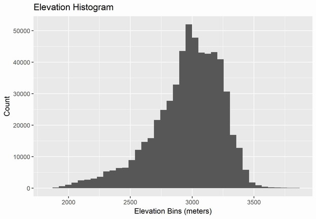

## Tree Type vs Elevation Density

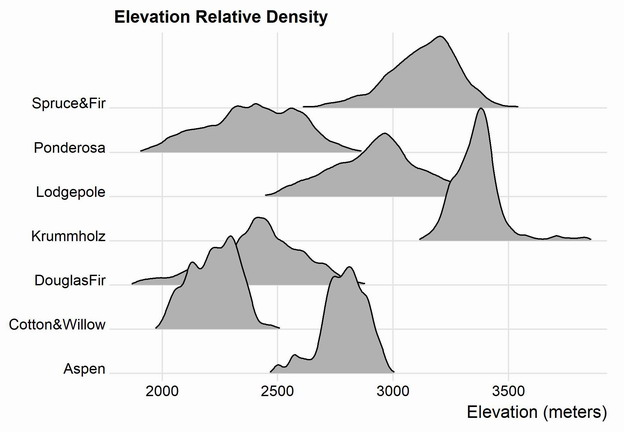

- Elevation can help determine tree type

## Coverage Frequency vs Climate

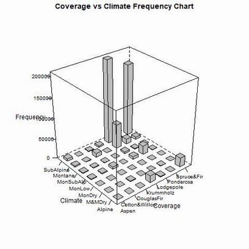

- Climate plays a varying role to determine tree type

## Tree Coverage vs Aspect

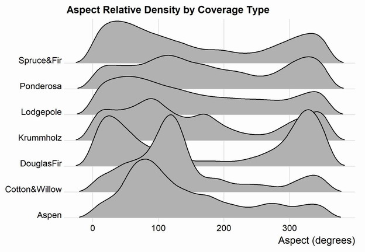

## Prediction Methodology

- Logistic Regression can only produce a true/false result
- Develop logistic regression models for each tree type on training data
- Final Model: Apply logistic models to data in a specific order
  - Highest Sensitivity first - only update if not already set
  - Lowest Specificity first - update even if already set
- Find best threshold for each model to produce best Final Model result
- Apply Final Model to test data

## Thresholds varied by Tree Model

| Model Description | Base | Acc | Sens | Spec | AUC | Count | Thresh |
| --- | --- | --- | --- | --- | --- | --- | --- |
| Ponderosa Agg | 93% | 92% | 97% | 91% | 97% | 10726 | 0.082 |
| Ponderosa Ind | 93% | 92% | 97% | 92% | 98% | 10726 | 0.068 |
| Douglas Fir Agg | 97% | 87% | 97% | 86% | 95% | 5210 | 0.033 |
| Cotton/Willow Agg | 99% | 95% | 94% | 95% | 98% | 824 | 0.008 |
| Aspen Ind | 98% | 68% | 93% | 68% | 87% | 2848 | 0.011 |
| Lodgepole Agg | 51% | 75% | 79% | 72% | 82% | 84990 | 0.482 |
| Spruce/Fir Agg | 63% | 73% | 87% | 66% | 83% | 63552 | 0.307 |
| Weighted Average |  | 76% | 84% | 72% |  | 174303 |  |

## Highest Sensitivity First - Confusion Matrix

| Tree | Aspen_Pre | Cot&Wil | DougFir | Krumm | Lodge | Ponder | Spr&Fir |
| --- | --- | --- | --- | --- | --- | --- | --- |
| Aspen_Act | 0 | 6 | 154 | 0 | 5870 | 471 | 144 |
| Cot&Wil | 0 | 1 | 25 | 0 | 9 | 1873 | 0 |
| DougFir | 0 | 78 | 2230 | 0 | 1554 | 8283 | 0 |
| Krumm | 0 | 0 | 0 | 8748 | 974 | 56 | 4554 |
| Lodge | 0 | 29 | 3583 | 326 | 142076 | 4946 | 47351 |
| Ponder | 0 | 23 | 682 | 0 | 2312 | 21888 | 0 |
| SprFir | 0 | 51 | 415 | 7146 | 33741 | 103 | 106816 |

## Highest Sensitivity First - Stats

| Tree | TP | FP | FN | TN | Accuracy | Sensitivity | Specificity |
| --- | --- | --- | --- | --- | --- | --- | --- |
| Aspen | 0 | 0 | 6645 | 399873 | 0.9836539 | 0.000000000 | 1.0000000 |
| CotWill | 1 | 187 | 1907 | 404423 | 0.9948489 | 0.000524109 | 0.9995378 |
| Ponder | 21888 | 15732 | 3017 | 365881 | 0.9538790 | 0.878859667 | 0.9587750 |
| SpruceFir | 106816 | 52049 | 41456 | 206197 | 0.7699856 | 0.720405741 | 0.7984519 |

Weighted Avg Sens= 0.692777882958086

Weighted Avg Spec= 0.818366298037202

Accuracy = 0.692777882958086

## Lowest Specificity First - Confusion Matrix

| Tree | Aspen_Pre | Cot&Wil | DougFir | Krumm | Lodge | Ponder | Spr&Fir |
| --- | --- | --- | --- | --- | --- | --- | --- |
| Aspen_Act | 260 | 0 | 119 | 0 | 5126 | 551 | 585 |
| Cot&Wil | 0 | 119 | 8 | 0 | 0 | 1772 | 3 |
| DougFir | 105 | 0 | 1778 | 0 | 1095 | 8877 | 292 |
| Krumm | 57 | 0 | 0 | 8272 | 80 | 56 | 5892 |
| Lodge | 2187 | 0 | 3231 | 270 | 140331 | 5959 | 46250 |
| Ponder | 581 | 60 | 503 | 0 | 705 | 22392 | 624 |
| SprFir | 1553 | 0 | 406 | 6292 | 34866 | 118 | 105053 |

## Lowest Specificity First - Stats

| Tree | TP | FP | FN | TN | Accuracy | Sensitivity | Specificity |
| --- | --- | --- | --- | --- | --- | --- | --- |
| Aspen | 260 | 4483 | 6381 | 395304 | 0.9732696 | 0.03915073 | 0.9887865 |
| CotWill | 119 | 60 | 1783 | 404466 | 0.9954654 | 0.06256572 | 0.9998517 |
| Ponder | 22392 | 17333 | 2473 | 364230 | 0.9512681 | 0.90054293 | 0.9545737 |
| SpruceFir | 105053 | 53646 | 43235 | 204494 | 0.7616281 | 0.70843898 | 0.7921825 |

Weighted Avg Sens= 0.684039448352508

Weighted Avg Spec= 0.82164066329442

Accuracy = 0.684039448352508

## Prediction Method Comparison

- Highest Sensitivity First Method
  - Slightly Higher Accuracy of 69.3%
  - Does not predict any Aspen and only 1 Cottonwood/Willow
- Lowest Specificity First Method
  - Slightly Lower Accuracy of 68.4%
  - Predicts more Aspen and Cottonwood/Willow
- Choose Lowest Specificity Method for Testing Set

## Testing Set - Confusion Matrix

| Tree | Aspen_Pre | Cot&Wil | DougFir | Krumm | Lodge | Ponder | Spr&Fir |
| --- | --- | --- | --- | --- | --- | --- | --- |
| Aspen_Act | 121 | 0 | 50 | 0 | 2199 | 237 | 240 |
| Cot&Wil | 0 | 38 | 9 | 0 | 0 | 769 | 0 |
| DougFir | 44 | 0 | 781 | 0 | 491 | 3772 | 116 |
| Krumm | 24 | 0 | 0 | 3495 | 38 | 22 | 2574 |
| Lodge | 954 | 0 | 1485 | 99 | 60175 | 2533 | 19706 |
| Ponder | 236 | 18 | 224 | 0 | 331 | 9587 | 257 |
| SprFir | 633 | 0 | 162 | 2805 | 14617 | 52 | 45283 |

## Testing Set - Stats

| Tree | TP | FP | FN | TN | Accuracy | Sensitivity | Specificity |
| --- | --- | --- | --- | --- | --- | --- | --- |
| Aspen | 121 | 1891 | 2726 | 169439 | 0.9734925 | 0.04250088 | 0.9889628 |
| CotWill | 38 | 18 | 778 | 173343 | 0.9954299 | 0.04656863 | 0.9998962 |
| Ponder | 9587 | 7385 | 1066 | 156139 | 0.9514804 | 0.89993429 | 0.9548384 |
| SpruceFir | 45283 | 22893 | 18269 | 87732 | 0.7636772 | 0.71253462 | 0.7930576 |

Weighted Avg Sens= 0.685472998169854

Weighted Avg Spec= 0.823379445775709

Accuracy = 0.685472998169854

## Conclusion

- 7 Combined Logistic Regression Model Performance
  - Achieved 68.5% Accuracy
  - 10% better than Discriminant Analysis
  - 1.5% worse than Neural Network
  - Did not come close to the top Kaggle competitor of 100%
- Thoughts on Logistic Regression
  - Gives insight into which variables are important for prediction
  - Weighted individual model performance does not give a good indication of combined model performance